# Investigating Delayed and Cancelled Flights

## by Omar Almedaihesh

## Investigation Overview

The target of this investigation is to know what causes a flight to be delayed or cancelled, when and where it happens more often, and for how long a flights are usually delayed for.

## Dataset Overview

The dataset consist of more than 7 million flights records for the year 2008. The dataset includes 29 features, most of which are numeric such as Departure/Arrival time, Departure/Arrival Delay. Also, some are non-numeric such as Origin, Destination, and Cancellation Code.

## Distribution of Departure Delay

The departure delay in the dataset vary over a long range, with the majority being on the lower end. The histogram is showing a right-skewed distribution as flights delayed for less than 5 minutes is the most common.

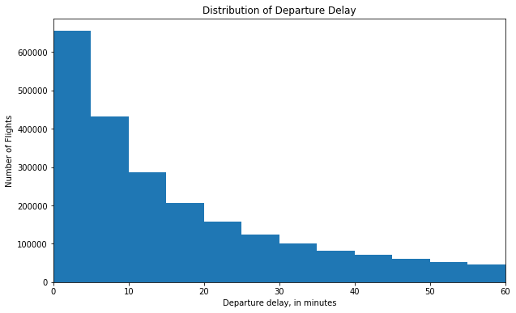

```python
#create the plot
bin_edges = np.arange(0, df.DepDelay.max()+5, 5)
plt.figure(figsize = [10, 6])
plt.hist(data= df_delayed, x ='DepDelay',bins = bin_edges)
plt.xlim((0,60))
plt.title('Distribution of Departure Delay')
plt.xlabel('Departure delay, in minutes')
plt.ylabel('Number of Flights')

plt.show()
```

## Cancelled Flights by Reason

The plot showing weather is the most common reason for flight cancellations. With carriers being ranked 2nd on the list with very similar number of flights. The plot also showing that it's very rare for flights being cancelled due to security reasons.

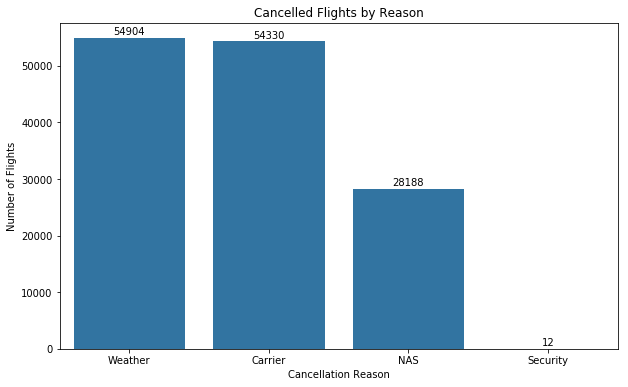

```python
#create the plot
base_color = sb.color_palette()[0]
cancel_counts = df.CancellationCode.value_counts()
plt.figure(figsize = [10, 6])
sb.countplot(data = df, x = 'CancellationCode', color = base_color, order = cancel_counts.index)
plt.title('Cancelled Flights by Reason')
plt.xlabel('Cancellation Reason')
plt.ylabel('Number of Flights')

#print the exact count above each bar
locs, labels = plt.xticks()
for loc, label in zip(locs, labels):
    count = cancel_counts[label.get_text()]
    plt.text(loc, count+600, count, ha = 'center', color = 'black')

plt.show()
```

## Departure Delay by Day Type

In the plot we can see that day type (weekday/weekend) has no effects on departure delay time. As both categories are almost identical with majority of flights falls between range of 5 to 40 minutes of departure delay.

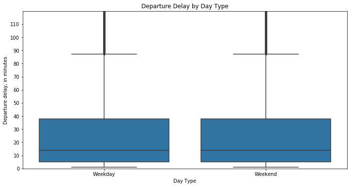

```python
#create the plot
plt.figure(figsize = [12, 6])

sb.boxplot(data = df_delayed, x = 'DayType', y = 'DepDelay', color = base_color)
plt.ylim((0,120))
plt.yticks(np.arange(0,120,10))
plt.title('Departure Delay by Day Type')
plt.xlabel('Day Type')
plt.ylabel('Departure delay, in minutes')
plt.show()
```

## Number of Monthly Cancelled Flights by Reason

In the plot we can see a relationship between winter (December to March), and flights being cancelled due to weather reasons. Overall, weather is the most common reason for flight cancellations, and it's clear that it happens more often during winter.

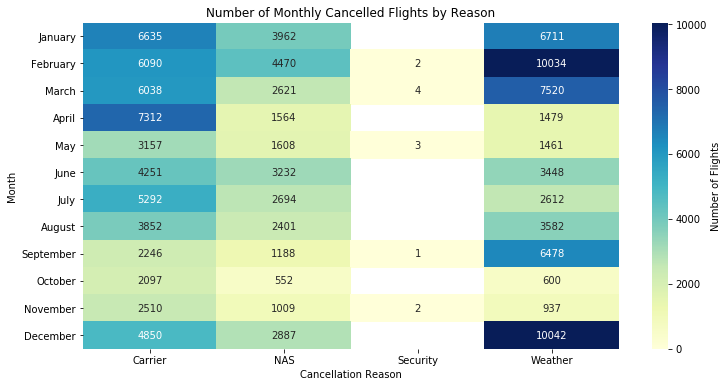

```python
#summarize the two variables of interest
ct_counts = df.groupby(['CancellationCode', 'Month']).size()
ct_counts = ct_counts.reset_index(name= 'count')
ct_counts = ct_counts.pivot(index = 'Month', columns = 'CancellationCode', values = 'count')
ct_counts.rename(index={1: 'January', 2: 'February', 3: 'March', 4: 'April', 5: 'May', 6: 'June', 7: 'July',
                        8: 'August', 9: 'September', 10: 'October', 11: 'November', 12: 'December'}, inplace = True)

#create the plot
plt.figure(figsize = [12, 6])
fig = sb.heatmap(ct_counts, annot= True, fmt= '.0f', cmap= 'YlGnBu', cbar_kws={'label': 'Number of Flights'})
plt.title('Number of Monthly Cancelled Flights by Reason')
plt.xlabel('Cancellation Reason')
plt.ylabel('Month')
plt.show()
```

## Average Departure Delay by Delay Probability

Each point in the plot represent an airport's average departure delay & probability of flight being delayed. While it's hard to say that there's a strong negative linear relationship, we can see that all airports with high average departure delay tend to have low delay probability.

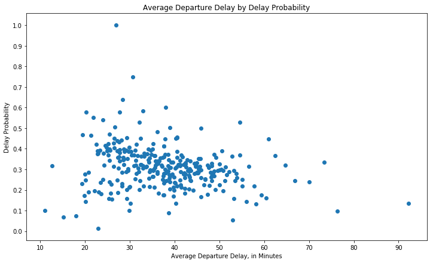

```python
#get delay probability and average delay for each airport
prob_delayed = df_delayed.Origin.value_counts().sort_index().values/df.Origin.value_counts().sort_index().values
avg_delayed = df_delayed.groupby('Origin')['DepDelay'].mean().values

#creata the plot
plt.figure(figsize = [12, 7])
plt.scatter(x= avg_delayed, y= prob_delayed)
plt.title('Average Departure Delay by Delay Probability')
plt.xlabel('Average Departure Delay, in Minutes')
plt.ylabel('Delay Probability')
plt.yticks(np.arange(0,1.1,.1))

plt.show()
```

## Departure Delay by Scheduled Departure Hour and Distance

The above plot showing that delayed flights which were originally scheduled to departue very late at night, tends to be a long distance flights.

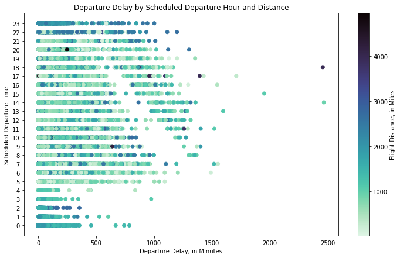

```python
#keep just the hour for better visualization in y axis
df_delayed['CRDepHour'] = df_delayed.CRSDepTime // 100

#create the plot
plt.figure(figsize = [12, 7])
plt.scatter(data = df_delayed, x = 'DepDelay', y = 'CRDepHour', c = 'Distance',
            cmap = 'mako_r')

plt.colorbar(label='Flight Distance, in Miles')
plt.title('Departure Delay by Scheduled Departure Hour and Distance')
plt.xlabel('Departure Delay, in Minutes')
plt.ylabel('Scheduled Departure Time')
plt.yticks(np.arange(0,23+1,1))

plt.show()
```